# Exercise Set 7: Solutions

# fpp3 8.8, Ex14

> 1. Use `ETS()` to select an appropriate model for the following series: total number of trips across Australia using `tourism`, the closing prices for the four stocks in `gafa_stock`, and the lynx series in `pelt`. Does it always give good forecasts?

### tourism

```r
aus_trips <- tourism %>%
  summarise(Trips = sum(Trips))
aus_trips %>%
  model(ETS(Trips)) %>%
  report()
```

```
## Series: Trips
## Model: ETS(A,A,A)
##   Smoothing parameters:
##     alpha = 0.4495675
##     beta  = 0.04450178
##     gamma = 0.0001000075
##
##   Initial states:
##      l[0]      b[0]      s[0]     s[-1]     s[-2]    s[-3]
##  21689.64 -58.46946 -125.8548 -816.3416 -324.5553 1266.752
##
##   sigma^2:  699901.4
##
##      AIC     AICc      BIC
## 1436.829 1439.400 1458.267
```

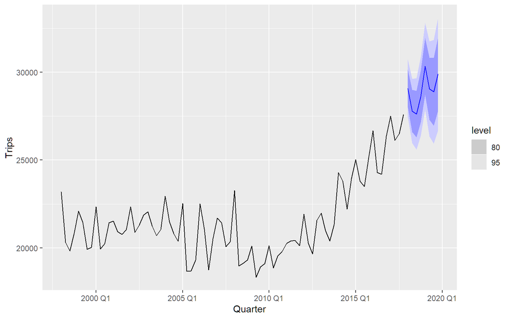

```r
aus_trips %>%
  model(ETS(Trips)) %>%
  forecast() %>%
  autoplot(aus_trips)
```

Forecasts appear reasonable.

### GAFA stock

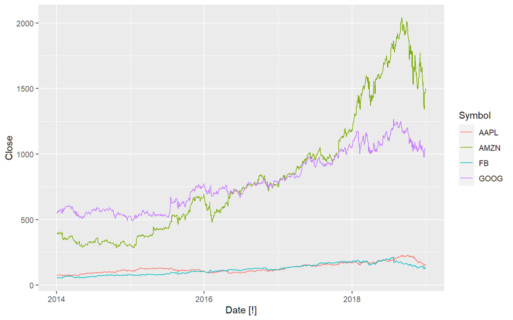

```r
gafa_regular <- gafa_stock %>%
  group_by(Symbol) %>%
  mutate(trading_day = row_number()) %>%
  ungroup() %>%
  as_tsibble(index = trading_day, regular = TRUE)

gafa_stock %>% autoplot(Close)
```

```r
gafa_regular %>%
  model(ETS(Close))
```

```
## # A mable: 4 x 2
## # Key:     Symbol [4]
##   Symbol `ETS(Close)`
##   <chr>       <model>
## 1 AAPL   <ETS(M,N,N)>
## 2 AMZN   <ETS(M,N,N)>
## 3 FB     <ETS(M,N,N)>
## 4 GOOG   <ETS(M,N,N)>
```

```
## `mutate_if()` ignored the following grouping variables:
## Column `Symbol`
```

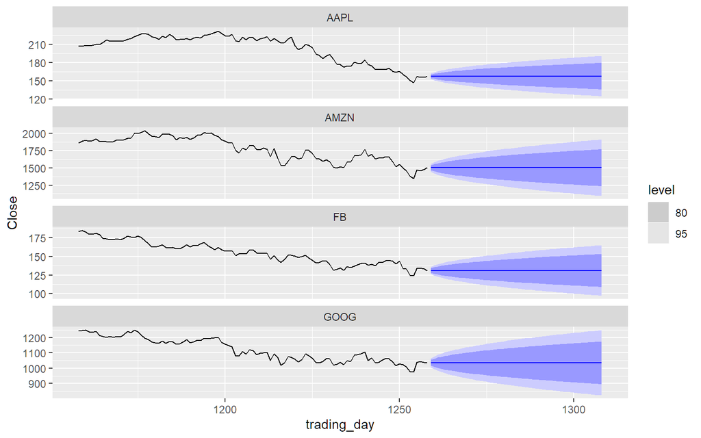

```r
gafa_regular %>%
  model(ETS(Close)) %>%
  forecast(h = 50) %>%
  autoplot(gafa_regular %>% group_by_key() %>% slice((n() - 100):n()))
```

Forecasts look reasonable for an efficient market.

### Pelt trading records

```r
pelt %>%
  model(ETS(Lynx))
```

```
## # A mable: 1 x 1
##    `ETS(Lynx)`
##        <model>
## 1 <ETS(A,N,N)>
```

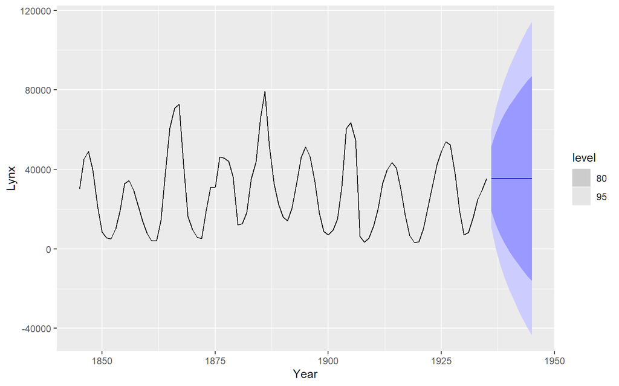

```r
pelt %>%
  model(ETS(Lynx)) %>%
  forecast(h = 10) %>%
  autoplot(pelt)
```

Here the cyclic behaviour of the lynx data is completely lost. ETS models are not designed to handle cyclic data, so there is nothing that can be done to improve this.

> 2. Find an example where it does not work well. Can you figure out why?

ETS does not work well on cyclic data, as seen in the pelt dataset above.

# fpp3 8.8, Ex15

> Show that the point forecasts from an ETS(M,A,M) model are the same as those obtained using Holt-Winters’ multiplicative method.

Point forecasts from the multiplicative Holt-Winters’ method:
$$\hat{y}_{t+h|t} = (\ell_t + hb_t)s_{t-m+h_m^+}$$

An ETS(M,A,M) model is given by
$$\begin{align*}
y_t & = (\ell_{t-1}+b_{t-1})s_{t-m}(1+\varepsilon_t) \\
\ell_t & = (\ell_{t-1}+b_{t-1})(1+\alpha\varepsilon_t) \\
b_t & = b_{t-1} + \beta(\ell_{t-1}+b_{t-1})\varepsilon_t \\
s_t & = s_{t-m} (1+\gamma\varepsilon_t)
\end{align*}$$
So $y_{T+h}$ is given by
$$y_{T+h} = (\ell_{T+h-1}+b_{T+h-1})s_{T+h-m}(1+\varepsilon_{T+h-m})$$
Replacing $\varepsilon_{t}$ by zero for $t>T$, and substituting in from the above equations, we obtain
$$\hat{y}_{T+h} = (\ell_{T+h-2}+2b_{T+h-2})s_{T+h-m}$$
Repeating the process a few times leads to
$$\hat{y}_{T+h} = (\ell_{T}+hb_{T})s_{T+h-m}$$
Doing the same thing for $s_{T+h-m}$ gives
$$\hat{y}_{T+h|T} = (\ell_{T}+hb_{T})s_{T+h_m^+-m}$$
as required.